# Chapter 8 Review; Chapter 9: Stocks

FINA 3000 · Business Finance I · Class 14

Dr. Justin Mohr

October 8, 2026

## Securities Market Line

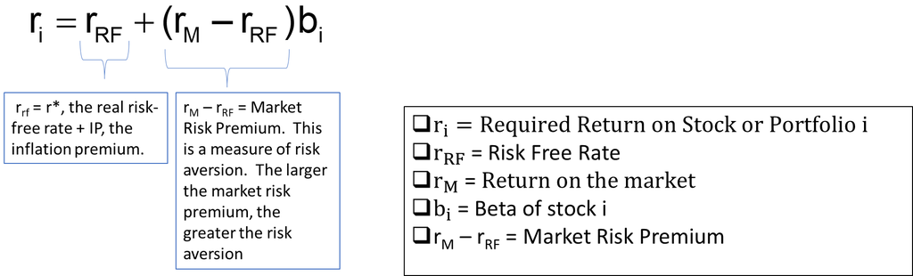

## SML

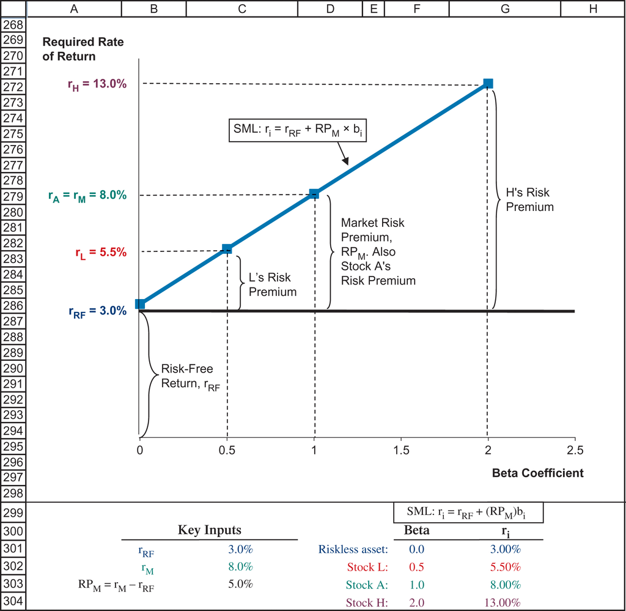

- $r_H$ has a beta of 2
- $r_A$ has a beta of 1
- $r_L$ has a beta of 0.5

$$r_i = r_{rf} + RP_m \ast b_i \qquad RP_m = 5\% \qquad r_{rf} = 3\%$$

## Factors that change the SML

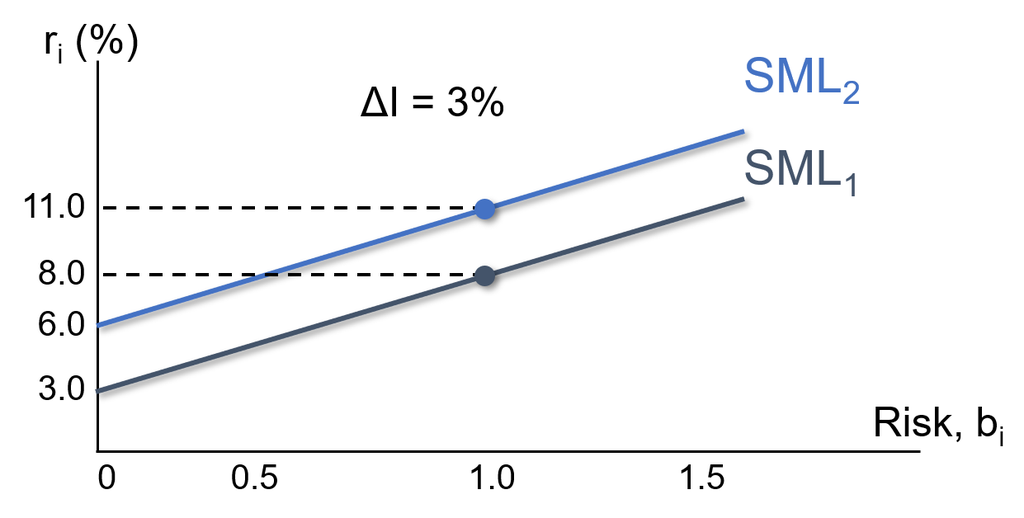

- Inflation
  - If inflation expectations increase then $r_{rf}$ increases
  - Shifts the line up the y axis

## Factors that change the SML

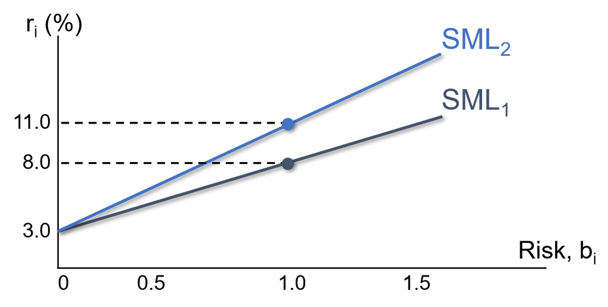

- If investors’ risk aversion increased, causing the market risk premium to increase by, the SML get steeper.
- Stocks with a greater Beta experience a greater increase in ri

## Portfolios

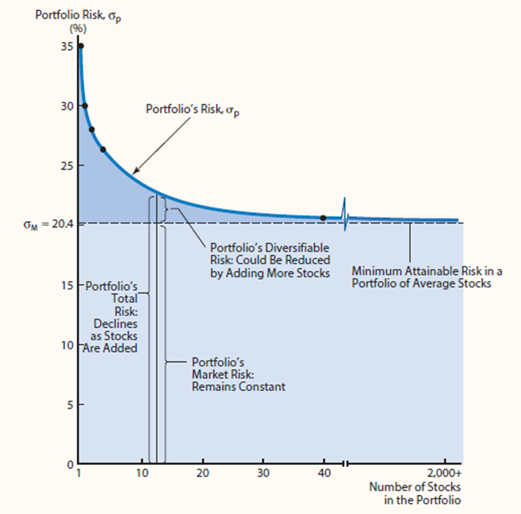

- σp decreases as stocks are added if they are not perfectly correlated with the existing portfolio.
- Expected return of the portfolio should remain relatively constant.
- Eventually the diversification benefits of adding more stocks dissipates (after about 40 stocks), and for large stock portfolios, σp tends to converge to ≈ 20%.

## Risk Return Framework

- The risk associated with a single stock includes:
- Diversifiable Risk (company-specific, unsystematic)
- Market Risk (non-diversifiable, systematic, due to macroeconomic variables)
- Well-diversified Portfolios
- As more and more assets are added to a portfolio, diversifiable risk gets eliminated
- Rational Investors will hold portfolios since portfolios eliminate diversifiable risk
- This leaves investors exposed to only market risk. Since σ includes diversifiable risk, a better measure of a stock’s risk is required.
- The relevant risk measure is Beta (β) which measures a stock’s sensitivity to changes in market returns

## Concept of Beta

- Beta(β) measures how the return of an individual stock (or even a portfolio) varies with the market.
- β = 1.0 : same risk (volatility) as the market
- β < 1.0 : less risky (less volatile) than the market
- β > 1.0 : more risky (more volatile) than the market
- β < 0 : moves in the opposite direction of the market
- Beta is the slope of the regression line (y = a + βx) between a stock’s return(y) and the market return(x) over time. β is derived from a simple linear regression.

# Chapter 9

Mohr

## What is equity?

- Ownership in the firm
- Claim on the profits of the firm, but also a right to control the firm!
- If you buy 10% of the shares in Justin’s Cupcakes, then you have the right to vote 10% of the votes
  - Vote on issues including the election of board members, merger or acquisition approvals, or approving a stock compensation plan.
- As long as I retain 51% I have control

## How do I vote?

- Typically, via proxy.
  - You have the right to show up to the annual meeting
  - But often you give someone the right to vote on your behalf

## How much is your vote worth

- Depends on the class of shares
- There are special privileges given to different classes of shares
  - Google Class A has 1 vote per share and Class B has 10 votes

## Intrinsic Value and Stock Price

- Investors are constantly trying to estimate a stock’s intrinsic value and use a variety of approaches to do so
- In equilibrium, a stock’s intrinsic value = market price
- Stock prices frequently deviate from intrinsic value
- The marginal investor will
  - purchase a stock when its market price < intrinsic value
  - sell a stock when its market price > intrinsic value
- Not all investors agree on a stock’s intrinsic value

## Intrinsic Values and Stock Prices

[figure not shown]

## Intrinsic Values and Stock Price

- Investors are constantly trying to estimate a stock’s intrinsic value and use a variety of approaches to do so
- In equilibrium, a stock’s intrinsic value = market price
- Stock prices frequently deviate from intrinsic value
- The marginal investor will
  - purchase a stock when its market price < intrinsic value
  - sell a stock when its market price > intrinsic value
- Not all investors agree on a stock’s intrinsic value

## Three Approaches for Intrinsic Value

- Discounted dividend model
- Corporate valuation model
- Market multiples

## Discounted Dividend Model

- You own a common share of Justin’s Cupcakes
- What are you entitled to?
  - Votes
  - Share of the revenue
- What revenue do we get from the firm?
  - Dividends!
  - When do we stop getting them?
    - NEVER!

## Discounted Dividend Model

- CFs are now dividend payments
- What is the PV of this stream of CF?
  - Well, what discount rate should we use?
- We use $r_s$! This is the rate of return we solved for last class!
  - The $r_i = r_{rf} + RP_m \ast \beta$

0 1 2 3 ∞

D<sub>1</sub> D<sub>2</sub> D<sub>3</sub> D<sub>∞</sub>

## Discounted Dividend Model

- CFs are now dividend payments
- What is the PV of this stream of CF?

$$PV = \frac{D_1}{1 + r_s} + \frac{D_2}{\left( 1 + r_s \right)^2} + \frac{D_3}{\left( 1 + r_s \right)^3} + ... + \frac{D_\infty}{\left( 1 + r_s \right)^\infty}$$

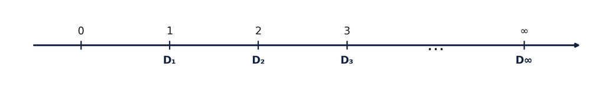

- Do you want to compute the PV of infinite CFs?
  - No!
- We have a math trick

## Assume constant dividend growth rate

- Then we can express

$$P_0 = \frac{D_1}{1 + r_s} + \frac{D_2}{\left( 1 + r_s \right)^2} + \frac{D_3}{\left( 1 + r_s \right)^3} + ... + \frac{D_\infty}{\left( 1 + r_s \right)^\infty}$$

- as

$$P_0 = \frac{D_1}{1 + r_s} + \frac{D_1 \left( 1 + g \right)}{\left( 1 + r_s \right)^2} + \frac{D_1 \left( 1 + g \right)^2}{\left( 1 + r_s \right)^3} + ... + \frac{D_1 \left( 1 + g \right)^\infty}{\left( 1 + r_s \right)^\infty}$$

- Some math trickery

$$P_0 = \frac{D_1}{r_s - g} = \frac{D_0 \left( 1 + g \right)}{r_s - g}$$

## Gordon Growth Model

- If I know the required rate of return, a dividend, and the growth rate of dividends, then I can find price

$$P_0 = \frac{D_1}{r_s - g} = \frac{D_0 \left( 1 + g \right)}{r_s - g}$$

- $r_s$ is the discount rate for the stock. We will use the CAPM to find it.

## Example

There is a stock with a $r_s$ of 9% and a $g$ of 3%. The next dividend paid will be $4.12. Find the price of the stock

## Stock Price

- Assumptions:
  - $r_{RF}$=Risk Free Rate=3%
  - $r_M$=Market Return=7%, therefore Market Risk Premium=4%
  - Springfield Nuclear Energy’s Beta (β)=1.5 (given)
  - D0=Current Dividend is $3.00 per share
  - Dividend growth rate (g) is constant 5%
- Find the estimated intrinsic value of the stock, $P_0$

## Answer: Stock Price

- Assumptions:
  - $r_{RF}$=Risk Free Rate=3%
  - $r_M$=Market Return=7%, therefore Market Risk Premium=4%
  - Springfield Nuclear Energy’s Beta (β)=1.5 (given)
  - D0=Current Dividend is $3.00 per share
  - Dividend growth rate (g) is constant 5%
- Find the estimated intrinsic value of the stock, $P_0$

## Acme Stock Price

- Assumptions:
  - Risk Free Rate=4%
  - Market Return=9%, therefore Market Risk Premium=5%
  - Acme Metals Beta=1.15 (given)
  - Current Dividend is $4.00 per share
  - Constant growth rate is 4%
- Find the stock’s intrinsic value

## Answer: Acme Stock Price

- Assumptions:
  - Risk Free Rate=4%
  - Market Return=9%, therefore Market Risk Premium=5%
  - Acme Metals Beta=1.15 (given)
  - Current Dividend is $4.00 per share
  - Constant growth rate is 4%
- Find the stock’s intrinsic value

## Let’s break our model

- Assumptions:
  - Risk Free Rate=4%
  - Market Return=10%, therefore Market Risk Premium=6%
  - Acme Metals Beta=-1.25 (given)
  - Current Dividend is $4.00 per share
  - Constant growth rate is 3%
- Find the stock’s intrinsic value

## Negative Price

- They will not pay us to own their stock.
- What happens if g > rs or g=0
  - If g > rs, the constant growth formula leads to a negative stock price, which does not make sense.
  - The Gordon Growth Model can be used only if:
  - rs > g and $D_1$ >0
  - g is expected to be constant forever.
  - If g=0, then $P_0$ = $\frac{D_1}{r_s}$
    - Same as preferred stock or a perpetuity

## Future Price

- What should the price at time 1 be?

$$P_1 = \frac{D_2}{r_s - g} = \frac{D_1 \left( 1 + g \right)}{r_s - g} = \frac{D_0 \left( 1 + g \right)^2}{r_s - g}$$

- Where does this come from?

$$D_{t+1} = D_t \left( 1 + g \right)$$

- So

$$D_2 = D_1 \left( 1 + g \right) \text{ and } D_1 = D_0 \left( 1 + g \right)$$

- Then

$$D_2 = D_0 \left( 1 + g \right)^2$$

## Future Price

- What should the price at time 1 be?

$$P_0 = \frac{D_1}{r_s - g} = \frac{D_0 \left( 1 + g \right)}{r_s - g} \qquad P_1 = \frac{D_2}{r_s - g} = \frac{D_1 \left( 1 + g \right)}{r_s - g} = \frac{D_0 \left( 1 + g \right)^2}{r_s - g}$$

- General result

$$P_t = \frac{D_{t+1}}{r_s - g}$$

- And

$$D_t = D_0 \left( 1 + g \right)^t$$

## Future Price

Forecast dividends growing at a constant 4%

| Forecast Dividends |  |  |  |  |
| --- | --- | --- | --- | --- |
| Growth |  | 4.00% | 4.00% | 4.00% |
| Year | 0 | 1 | 2 | 3 |
| Dividend | $2.00 | $2.08 | $2.16 | $2.25 |

Find the price of the stock at time 0 and time 1

- D0=$2
- g is constant and=4%
- $r_s$=9%

## Decomposing return

- Our stock return can be split to the dividend yield and the capital gains yield

$$r_s = \frac{D_1}{P_0} + \frac{P_1 - P_0}{P_0}$$

- Take our last example with a price today of $41.60, a dividend next period of $2.08, $r_s$ =9%, and a price next period of $43.26

## Upcoming Dates

Upcoming class dates and deadlines

| Date | Topic | Due / Notes |
| --- | --- | --- |
| Sun Oct 11 | MindTap Ch 8 | HW DUE |
| Mon Oct 12 | Deadline for course withdrawals (no refund; refund period ended September 4th) | DEADLINE |
| Tue Oct 13 | Review for Test 2 | Review |
| Thu Oct 15 | Test 2 | EXAM |

**Office:** 325 Holman Hall · **Office hours:** T TH 10:50A-12:20P · jjmohr1@olemiss.edu